# Prediction of Student Performance in Secondary Education

##### Down-Sampled Train Set

```r
down_knn_clf <- train_model_clf("knn", train_set_clf_down)
```

```
## k-Nearest Neighbors
##
## 160 samples
##  32 predictor
##   2 classes: 'fail', 'pass'
##
## Pre-processing: centered (72), scaled (72)
## Resampling: Cross-Validated (10 fold, repeated 10 times)
## Summary of sample sizes: 144, 144, 144, 144, 144, 144, ...
## Resampling results across tuning parameters:
##
##   k  Accuracy  Kappa
##   5  0.714375  0.42875
##   7  0.715625  0.43125
##   9  0.727500  0.45500
##
## Accuracy was used to select the optimal model using the largest value.
## The final value used for the model was k = 9.
```

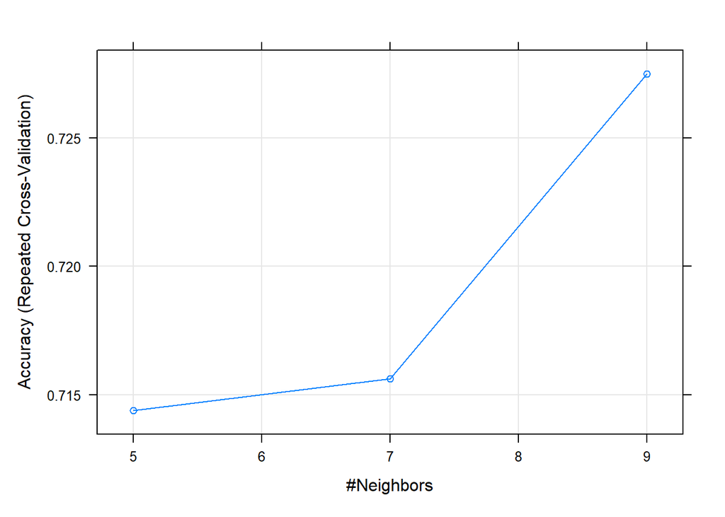

```r
plot(down_knn_clf)
```

Perform hyperparameter tuning using `tuneGrid`.

```r
down_knn_clf <- train_model_clf(
  "knn",
  train_set_clf_down,
  tuneGrid = expand.grid(k = c(9, 11, 13, 15))
)
```

```
## k-Nearest Neighbors
##
## 160 samples
##  32 predictor
##   2 classes: 'fail', 'pass'
##
## Pre-processing: centered (72), scaled (72)
## Resampling: Cross-Validated (10 fold, repeated 10 times)
## Summary of sample sizes: 144, 144, 144, 144, 144, 144, ...
## Resampling results across tuning parameters:
##
##   k   Accuracy  Kappa
##    9  0.726875  0.45375
##   11  0.729375  0.45875
##   13  0.736875  0.47375
##   15  0.727500  0.45500
##
## Accuracy was used to select the optimal model using the largest value.
## The final value used for the model was k = 13.
```

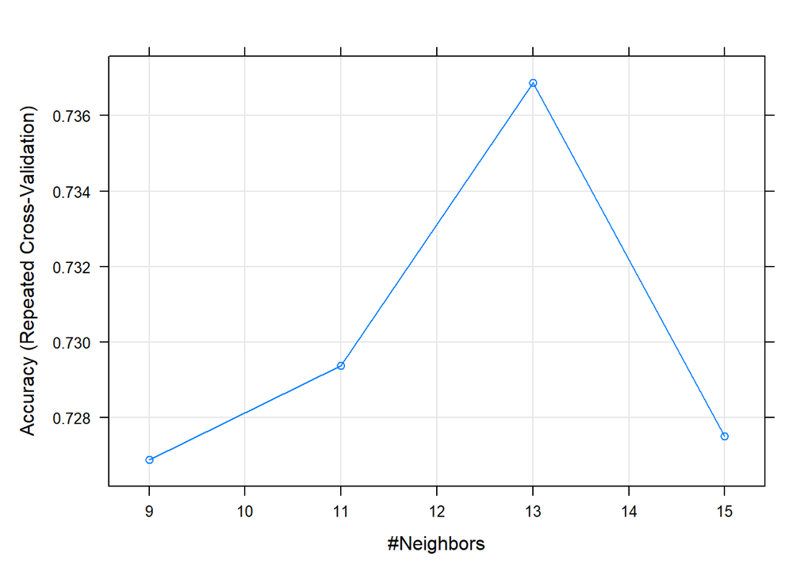

```r
plot(down_knn_clf)
```

No further tuning required.

```r
down_knn_metrics_clf <- evaluate_model_clf(down_knn_clf, "K-Nearest Neighbors")
```

```
## Confusion Matrix and Statistics
##
##           Reference
## Prediction fail pass
##       fail   16   15
##       pass    4   94
##
##                Accuracy : 0.8527
##                  95% CI : (0.7796, 0.9089)
##     No Information Rate : 0.845
##     P-Value [Acc > NIR] : 0.46267
##
##                   Kappa : 0.5409
##
##  Mcnemar's Test P-Value : 0.02178
##
##               Precision : 0.5161
##                  Recall : 0.8000
##                      F1 : 0.6275
##              Prevalence : 0.1550
##          Detection Rate : 0.1240
##    Detection Prevalence : 0.2403
##       Balanced Accuracy : 0.8312
##
##        'Positive' Class : fail
##
```

##### Up-Sampled Train Set

```r
up_knn_clf <- train_model_clf("knn", train_set_clf_up)
```

```
## k-Nearest Neighbors
##
## 880 samples
##  32 predictor
##   2 classes: 'fail', 'pass'
##
## Pre-processing: centered (72), scaled (72)
## Resampling: Cross-Validated (10 fold, repeated 10 times)
## Summary of sample sizes: 792, 792, 792, 792, 792, 792, ...
## Resampling results across tuning parameters:
##
##   k  Accuracy   Kappa
##   5  0.8503409  0.7006818
##   7  0.8335227  0.6670455
##   9  0.8397727  0.6795455
##
## Accuracy was used to select the optimal model using the largest value.
## The final value used for the model was k = 5.
```

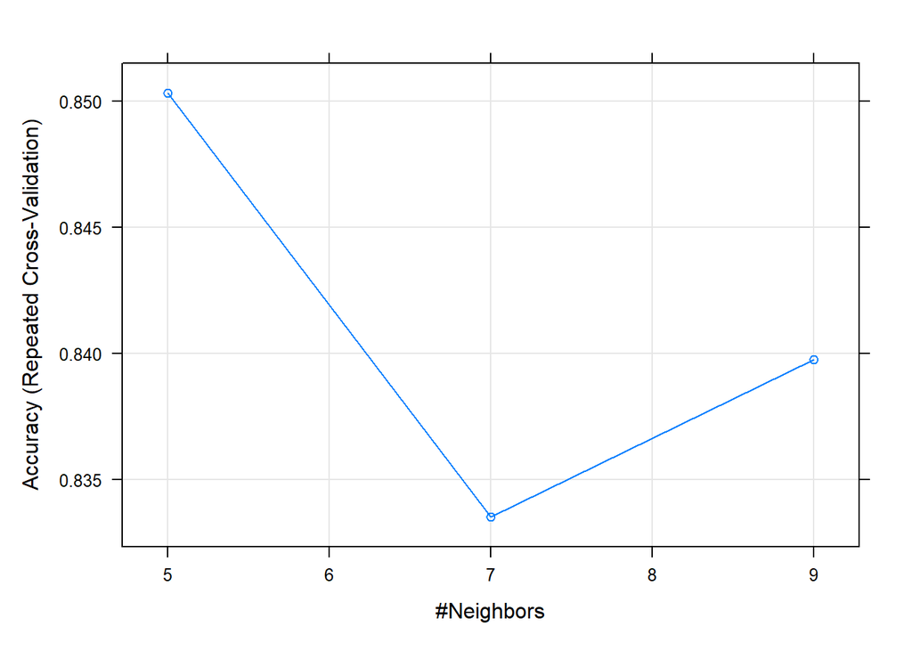

```r
plot(up_knn_clf)
```

Perform hyperparameter tuning using `tuneGrid`.

```r
up_knn_clf <- train_model_clf(
  "knn",
  train_set_clf_up,
  tuneGrid = expand.grid(k = c(1, 3, 5))
)
```

```
## k-Nearest Neighbors
##
## 880 samples
##  32 predictor
##   2 classes: 'fail', 'pass'
##
## Pre-processing: centered (72), scaled (72)
## Resampling: Cross-Validated (10 fold, repeated 10 times)
## Summary of sample sizes: 792, 792, 792, 792, 792, 792, ...
## Resampling results across tuning parameters:
##
##   k  Accuracy   Kappa
##   1  0.9648864  0.9297727
##   3  0.8918182  0.7836364
##   5  0.8507955  0.7015909
##
## Accuracy was used to select the optimal model using the largest value.
## The final value used for the model was k = 1.
```

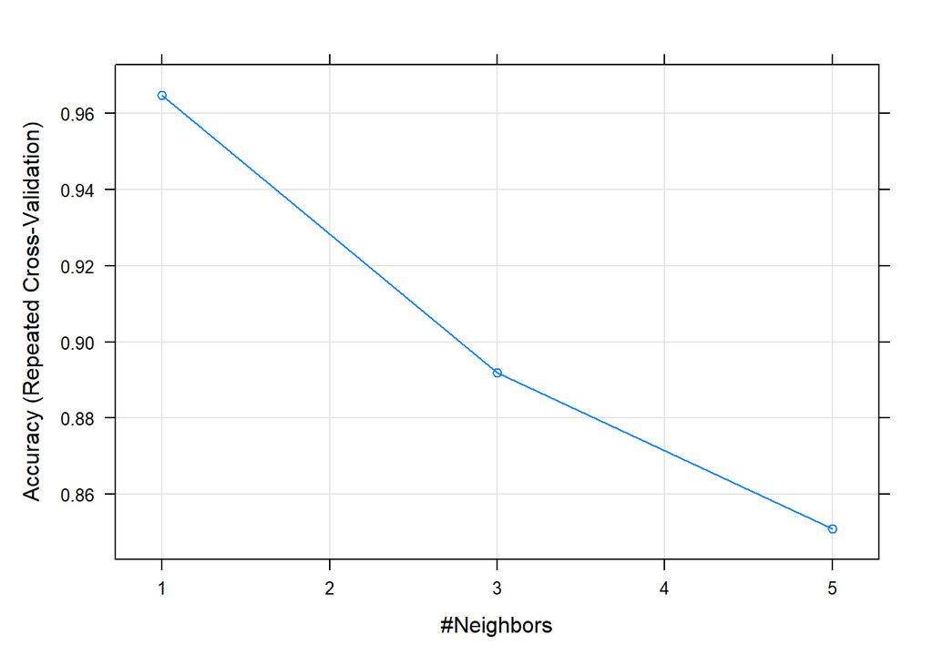

```r
plot(up_knn_clf)
```

Tuning done.

```r
up_knn_metrics_clf <- evaluate_model_clf(up_knn_clf, "K-Nearest Neighbors")
```

```
## Confusion Matrix and Statistics
##
##           Reference
## Prediction fail pass
##       fail   10    4
##       pass   10  105
##
##                Accuracy : 0.8915
##                  95% CI : (0.8246, 0.9394)
##     No Information Rate : 0.845
##     P-Value [Acc > NIR] : 0.08614
##
##                   Kappa : 0.528
##
##  Mcnemar's Test P-Value : 0.18145
##
##               Precision : 0.71429
##                  Recall : 0.50000
##                      F1 : 0.58824
##              Prevalence : 0.15504
##          Detection Rate : 0.07752
##    Detection Prevalence : 0.10853
##       Balanced Accuracy : 0.73165
##
##        'Positive' Class : fail
##
```

#### 5. Logistic Regression

- method = ‘glmnet’
- Type: Regression, Classification
- Tuning parameters:
  - alpha (Mixing Percentage)
  - lambda (Regularization Parameter)
- Required packages: glmnet, Matrix
- A model-specific variable importance metric is available.

##### Original Train Set

```r
lr_clf <- train_model_clf("glmnet")
```

```
## glmnet
##
## 520 samples
##  32 predictor
##   2 classes: 'fail', 'pass'
##
## Pre-processing: centered (72), scaled (72)
## Resampling: Cross-Validated (10 fold, repeated 10 times)
## Summary of sample sizes: 468, 468, 468, 468, 468, 468, ...
## Resampling results across tuning parameters:
##
##   alpha  lambda        Accuracy   Kappa
##   0.10   0.0004322165  0.9017308  0.6256426
##   0.10   0.0043221649  0.9159615  0.6555571
##   0.10   0.0432216490  0.9109615  0.5802518
##   0.55   0.0004322165  0.9030769  0.6312819
##   0.55   0.0043221649  0.9261538  0.6950640
##   0.55   0.0432216490  0.9128846  0.5716085
##   1.00   0.0004322165  0.9015385  0.6298148
##   1.00   0.0043221649  0.9284615  0.7077239
##   1.00   0.0432216490  0.9203846  0.6030193
##
## Accuracy was used to select the optimal model using the largest value.
## The final values used for the model were alpha = 1 and lambda = 0.004322165.
```

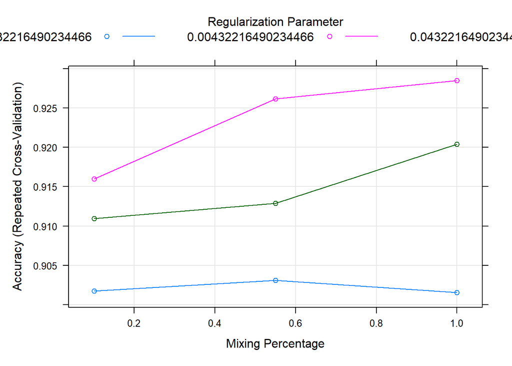

```r
plot(lr_clf)
```

Check for tuning using `tuneLength`.

```r
lr_clf <- train_model_clf("glmnet", tuneLength = 10)
```

```
## glmnet
##
## 520 samples
##  32 predictor
##   2 classes: 'fail', 'pass'
##
## Pre-processing: centered (72), scaled (72)
## Resampling: Cross-Validated (10 fold, repeated 10 times)
## Summary of sample sizes: 468, 468, 468, 468, 468, 468, ...
## Resampling results across tuning parameters:
##
##   alpha  lambda        Accuracy   Kappa
##   0.1    9.984762e-05  0.8967308  0.60779310
##   0.1    2.306609e-04  0.8969231  0.60876498
##   0.1    5.328567e-04  0.9040385  0.63297908
##   0.1    1.230968e-03  0.9090385  0.64326112
##   0.1    2.843696e-03  0.9151923  0.65804902
##   0.1    6.569306e-03  0.9184615  0.65913957
##   0.1    1.517595e-02  0.9198077  0.65281748
##   0.1    3.505841e-02  0.9130769  0.60057173
##   0.1    8.098948e-02  0.8980769  0.48352832
##   0.1    1.870962e-01  0.8776923  0.31219660
##   0.2    9.984762e-05  0.8913462  0.58816286
##   0.2    2.306609e-04  0.8967308  0.60780293
##   0.2    5.328567e-04  0.9044231  0.63496540
##   0.2    1.230968e-03  0.9092308  0.64428003
##   0.2    2.843696e-03  0.9159615  0.66058001
##   0.2    6.569306e-03  0.9211538  0.66934419
##   0.2    1.517595e-02  0.9203846  0.65342998
##   0.2    3.505841e-02  0.9157692  0.61160217
##   0.2    8.098948e-02  0.8973077  0.47412016
##   0.2    1.870962e-01  0.8661538  0.20053350
##   0.3    9.984762e-05  0.8901923  0.58434279
##   0.3    2.306609e-04  0.8971154  0.60961696
##   0.3    5.328567e-04  0.9048077  0.63646919
##   0.3    1.230968e-03  0.9115385  0.65316063
##   0.3    2.843696e-03  0.9192308  0.67163219
##   0.3    6.569306e-03  0.9228846  0.67443623
##   0.3    1.517595e-02  0.9228846  0.66222271
##   0.3    3.505841e-02  0.9163462  0.61071768
```

[output cut: 60 more lines]

```
##   0.9    8.098948e-02  0.8773077  0.29712216
##   0.9    1.870962e-01  0.8461538  0.00000000
##   1.0    9.984762e-05  0.8896154  0.58740072
##   1.0    2.306609e-04  0.8930769  0.59910168
##   1.0    5.328567e-04  0.9051923  0.64221568
##   1.0    1.230968e-03  0.9180769  0.68455273
##   1.0    2.843696e-03  0.9257692  0.70368923
##   1.0    6.569306e-03  0.9305769  0.71375472
##   1.0    1.517595e-02  0.9296154  0.70099041
##   1.0    3.505841e-02  0.9275000  0.65591012
##   1.0    8.098948e-02  0.8740385  0.26875886
##   1.0    1.870962e-01  0.8461538  0.00000000
##
## Accuracy was used to select the optimal model using the largest value.
## The final values used for the model were alpha = 0.9 and lambda = 0.006569306.
```

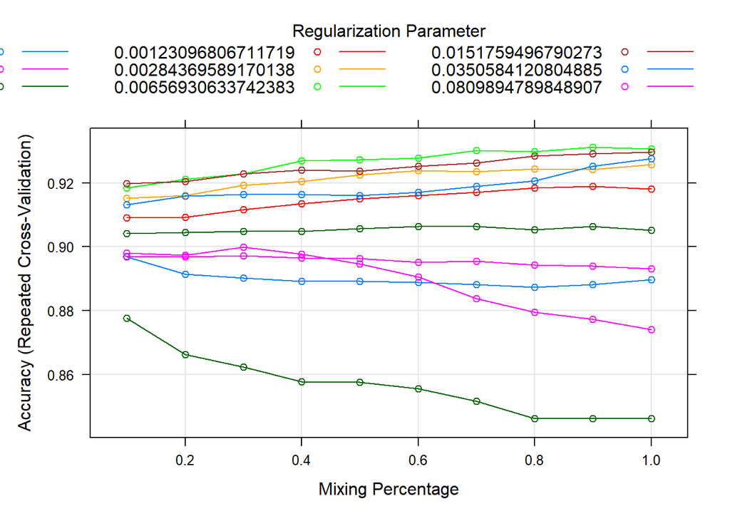

```r
plot(lr_clf)
```

No further tuning necessary.

```r
lr_metrics_clf <- evaluate_model_clf(lr_clf, "Logistic Regression")
```

```
## Confusion Matrix and Statistics
##
##           Reference
## Prediction fail pass
##       fail   14    5
##       pass    6  104
##
##                Accuracy : 0.9147
##                  95% CI : (0.8525, 0.9567)
##     No Information Rate : 0.845
##     P-Value [Acc > NIR] : 0.01442
##
##                   Kappa : 0.6678
##
##  Mcnemar's Test P-Value : 1.00000
##
##               Precision : 0.7368
##                  Recall : 0.7000
##                      F1 : 0.7179
##              Prevalence : 0.1550
##          Detection Rate : 0.1085
##    Detection Prevalence : 0.1473
##       Balanced Accuracy : 0.8271
##
##        'Positive' Class : fail
##
```

##### Down-Sampled Train Set

```r
down_lr_clf <- train_model_clf("glmnet", train_set_clf_down)
```

```
## glmnet
##
## 160 samples
##  32 predictor
##   2 classes: 'fail', 'pass'
##
## Pre-processing: centered (72), scaled (72)
## Resampling: Cross-Validated (10 fold, repeated 10 times)
## Summary of sample sizes: 144, 144, 144, 144, 144, 144, ...
## Resampling results across tuning parameters:
##
##   alpha  lambda        Accuracy  Kappa
##   0.10   0.0007071498  0.775000  0.55000
##   0.10   0.0070714983  0.792500  0.58500
##   0.10   0.0707149828  0.821875  0.64375
##   0.55   0.0007071498  0.791875  0.58375
##   0.55   0.0070714983  0.833125  0.66625
##   0.55   0.0707149828  0.858125  0.71625
##   1.00   0.0007071498  0.809375  0.61875
##   1.00   0.0070714983  0.839375  0.67875
##   1.00   0.0707149828  0.875000  0.75000
##
## Accuracy was used to select the optimal model using the largest value.
## The final values used for the model were alpha = 1 and lambda = 0.07071498.
```

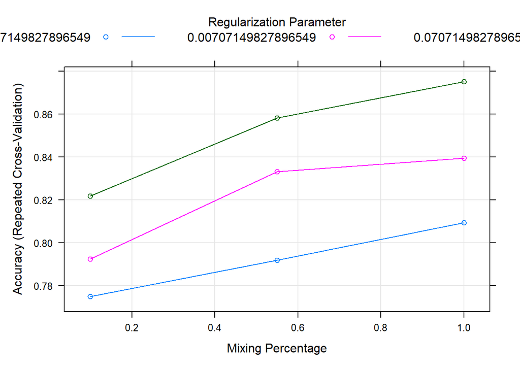

```r
plot(down_lr_clf)
```

Perform hyperparameter tuning using `tuneLength`.

```r
down_lr_clf <- train_model_clf("glmnet", train_set_clf_down, tuneLength = 10)
```

```
## glmnet
##
## 160 samples
##  32 predictor
##   2 classes: 'fail', 'pass'
##
## Pre-processing: centered (72), scaled (72)
## Resampling: Cross-Validated (10 fold, repeated 10 times)
## Summary of sample sizes: 144, 144, 144, 144, 144, 144, ...
## Resampling results across tuning parameters:
##
##   alpha  lambda        Accuracy  Kappa
##   0.1    0.0001633608  0.772500  0.54500
##   0.1    0.0003773846  0.773125  0.54625
##   0.1    0.0008718074  0.775625  0.55125
##   0.1    0.0020139881  0.775000  0.55000
##   0.1    0.0046525737  0.781875  0.56375
##   0.1    0.0107480486  0.798125  0.59625
##   0.1    0.0248293863  0.808750  0.61750
##   0.1    0.0573591027  0.823750  0.64750
##   0.1    0.1325069668  0.821875  0.64375
##   0.1    0.3061082795  0.829375  0.65875
##   0.2    0.0001633608  0.770000  0.54000
##   0.2    0.0003773846  0.773125  0.54625
##   0.2    0.0008718074  0.777500  0.55500
##   0.2    0.0020139881  0.783125  0.56625
##   0.2    0.0046525737  0.800000  0.60000
##   0.2    0.0107480486  0.811875  0.62375
##   0.2    0.0248293863  0.820000  0.64000
##   0.2    0.0573591027  0.831875  0.66375
##   0.2    0.1325069668  0.833750  0.66750
##   0.2    0.3061082795  0.856250  0.71250
##   0.3    0.0001633608  0.770625  0.54125
##   0.3    0.0003773846  0.777500  0.55500
##   0.3    0.0008718074  0.783125  0.56625
##   0.3    0.0020139881  0.793125  0.58625
##   0.3    0.0046525737  0.809375  0.61875
##   0.3    0.0107480486  0.820625  0.64125
##   0.3    0.0248293863  0.831875  0.66375
##   0.3    0.0573591027  0.843125  0.68625
```

[output cut: 60 more lines]

```
##   0.9    0.1325069668  0.874375  0.74875
##   0.9    0.3061082795  0.871250  0.74250
##   1.0    0.0001633608  0.801875  0.60375
##   1.0    0.0003773846  0.808750  0.61750
##   1.0    0.0008718074  0.808125  0.61625
##   1.0    0.0020139881  0.815625  0.63125
##   1.0    0.0046525737  0.826875  0.65375
##   1.0    0.0107480486  0.846875  0.69375
##   1.0    0.0248293863  0.863750  0.72750
##   1.0    0.0573591027  0.866875  0.73375
##   1.0    0.1325069668  0.874375  0.74875
##   1.0    0.3061082795  0.860000  0.72000
##
## Accuracy was used to select the optimal model using the largest value.
## The final values used for the model were alpha = 0.5 and lambda = 0.3061083.
```

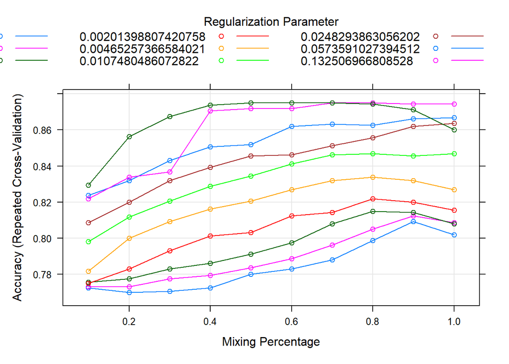

```r
plot(down_lr_clf)
```

No further tuning required.

```r
down_lr_metrics_clf <- evaluate_model_clf(down_lr_clf, "Logistic Regression")
```

```
## Confusion Matrix and Statistics
##
##           Reference
## Prediction fail pass
##       fail   18   14
##       pass    2   95
##
##                Accuracy : 0.876
##                  95% CI : (0.8064, 0.9274)
##     No Information Rate : 0.845
##     P-Value [Acc > NIR] : 0.19935
##
##                   Kappa : 0.6197
##
##  Mcnemar's Test P-Value : 0.00596
##
##               Precision : 0.5625
##                  Recall : 0.9000
##                      F1 : 0.6923
##              Prevalence : 0.1550
##          Detection Rate : 0.1395
##    Detection Prevalence : 0.2481
##       Balanced Accuracy : 0.8858
##
##        'Positive' Class : fail
##
```

##### Up-Sampled Train Set

```r
up_lr_clf <- train_model_clf("glmnet", train_set_clf_up)
```

```
## glmnet
##
## 880 samples
##  32 predictor
##   2 classes: 'fail', 'pass'
##
## Pre-processing: centered (72), scaled (72)
## Resampling: Cross-Validated (10 fold, repeated 10 times)
## Summary of sample sizes: 792, 792, 792, 792, 792, 792, ...
## Resampling results across tuning parameters:
##
##   alpha  lambda        Accuracy   Kappa
##   0.10   0.0007324895  0.9494318  0.8988636
##   0.10   0.0073248947  0.9317045  0.8634091
##   0.10   0.0732489472  0.9007955  0.8015909
##   0.55   0.0007324895  0.9505682  0.9011364
##   0.55   0.0073248947  0.9282955  0.8565909
##   0.55   0.0732489472  0.9080682  0.8161364
##   1.00   0.0007324895  0.9540909  0.9081818
##   1.00   0.0073248947  0.9336364  0.8672727
##   1.00   0.0732489472  0.9146591  0.8293182
##
## Accuracy was used to select the optimal model using the largest value.
## The final values used for the model were alpha = 1 and lambda = 0.0007324895.
```

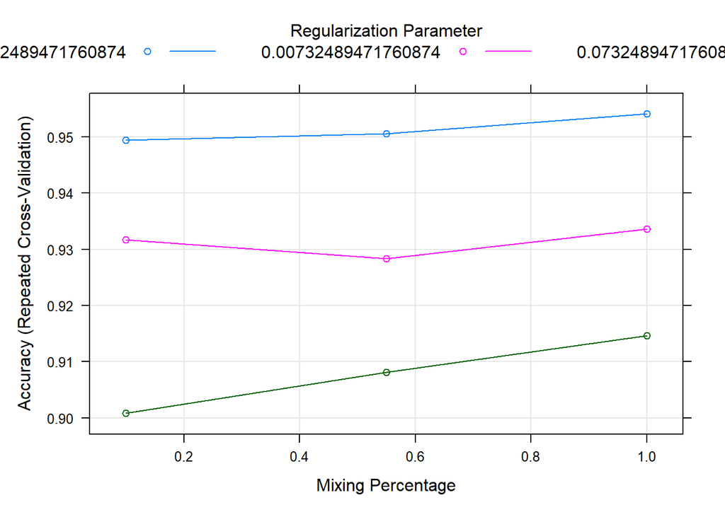

```r
plot(up_lr_clf)
```

Perform hyperparameter tuning using `tuneLength`.

```r
up_lr_clf <- train_model_clf("glmnet", train_set_clf_up, tuneLength = 10)
```

```
## glmnet
##
## 880 samples
##  32 predictor
##   2 classes: 'fail', 'pass'
##
## Pre-processing: centered (72), scaled (72)
## Resampling: Cross-Validated (10 fold, repeated 10 times)
## Summary of sample sizes: 792, 792, 792, 792, 792, 792, ...
## Resampling results across tuning parameters:
##
##   alpha  lambda        Accuracy   Kappa
##   0.1    0.0001692146  0.9523864  0.9047727
##   0.1    0.0003909076  0.9522727  0.9045455
##   0.1    0.0009030473  0.9486364  0.8972727
##   0.1    0.0020861563  0.9423864  0.8847727
##   0.1    0.0048192916  0.9367045  0.8734091
##   0.1    0.0111331887  0.9256818  0.8513636
##   0.1    0.0257191098  0.9120455  0.8240909
##   0.1    0.0594144794  0.9030682  0.8061364
##   0.1    0.1372551534  0.8931818  0.7863636
##   0.1    0.3170772064  0.8892045  0.7784091
##   0.2    0.0001692146  0.9532955  0.9065909
##   0.2    0.0003909076  0.9525000  0.9050000
##   0.2    0.0009030473  0.9484091  0.8968182
##   0.2    0.0020861563  0.9431818  0.8863636
##   0.2    0.0048192916  0.9364773  0.8729545
##   0.2    0.0111331887  0.9221591  0.8443182
##   0.2    0.0257191098  0.9101136  0.8202273
##   0.2    0.0594144794  0.9002273  0.8004545
##   0.2    0.1372551534  0.8981818  0.7963636
##   0.2    0.3170772064  0.8769318  0.7538636
##   0.3    0.0001692146  0.9540909  0.9081818
##   0.3    0.0003909076  0.9527273  0.9054545
##   0.3    0.0009030473  0.9484091  0.8968182
##   0.3    0.0020861563  0.9444318  0.8888636
##   0.3    0.0048192916  0.9356818  0.8713636
##   0.3    0.0111331887  0.9207955  0.8415909
##   0.3    0.0257191098  0.9115909  0.8231818
##   0.3    0.0594144794  0.9045455  0.8090909
```

[output cut: 60 more lines]

```
##   0.9    0.1372551534  0.9071591  0.8143182
##   0.9    0.3170772064  0.9013636  0.8027273
##   1.0    0.0001692146  0.9561364  0.9122727
##   1.0    0.0003909076  0.9563636  0.9127273
##   1.0    0.0009030473  0.9543182  0.9086364
##   1.0    0.0020861563  0.9460227  0.8920455
##   1.0    0.0048192916  0.9359091  0.8718182
##   1.0    0.0111331887  0.9344318  0.8688636
##   1.0    0.0257191098  0.9306818  0.8613636
##   1.0    0.0594144794  0.9147727  0.8295455
##   1.0    0.1372551534  0.9043182  0.8086364
##   1.0    0.3170772064  0.8839773  0.7679545
##
## Accuracy was used to select the optimal model using the largest value.
## The final values used for the model were alpha = 1 and lambda = 0.0003909076.
```

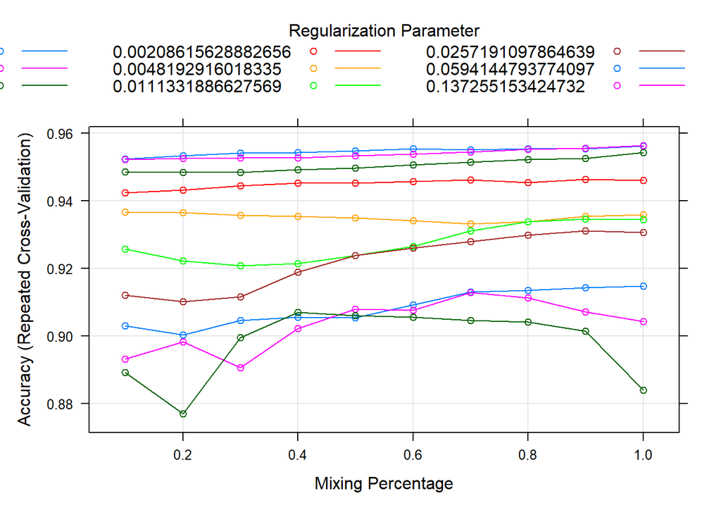

```r
plot(up_lr_clf)
```

Tuning done.

```r
up_lr_metrics_clf <- evaluate_model_clf(up_lr_clf, "Logistic Regression")
```

```
## Confusion Matrix and Statistics
##
##           Reference
## Prediction fail pass
##       fail   12    7
##       pass    8  102
##
##                Accuracy : 0.8837
##                  95% CI : (0.8155, 0.9334)
##     No Information Rate : 0.845
##     P-Value [Acc > NIR] : 0.1352
##
##                   Kappa : 0.5469
##
##  Mcnemar's Test P-Value : 1.0000
##
##               Precision : 0.63158
##                  Recall : 0.60000
##                      F1 : 0.61538
##              Prevalence : 0.15504
##          Detection Rate : 0.09302
##    Detection Prevalence : 0.14729
##       Balanced Accuracy : 0.76789
##
##        'Positive' Class : fail
##
```

### Evaluation

#### Regression

##### By RMSE

```r
df_eval_reg <- rbind(
  dt_reg$metrics,
  rf_reg_manual_tune$metrics,
  svm_reg$metrics,
  xgb_reg_manual_tune$metrics,
  lr_reg_manual_tune$metrics
)

df_eval_reg <- df_eval_reg[order(df_eval_reg$RMSE), ]
row.names(df_eval_reg) <- NULL
df_eval_reg
```

```
##                    Model     RMSE  Rsquared       MAE
## 1          Random Forest 1.106174 0.8666637 0.7717890
## 2      Linear Regression 1.117378 0.8643585 0.7226734
## 3 Support Vector Machine 1.177426 0.8521626 0.7618882
## 4                XGBoost 1.250256 0.8338254 0.8697652
## 5          Decision Tree 1.340746 0.8114244 0.8614620
```

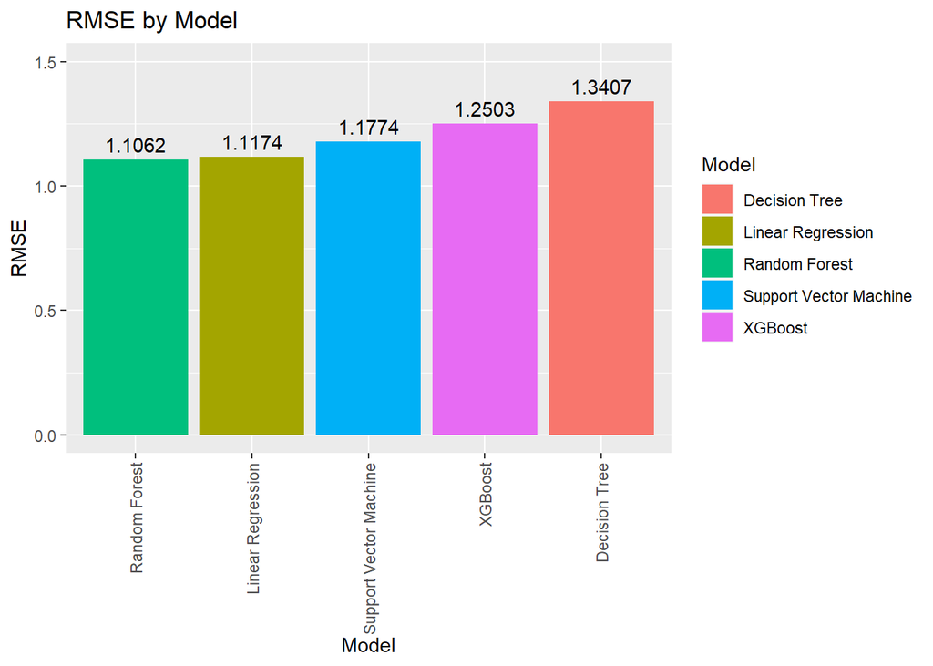

```r
df_eval_reg["RMSE"] <- round(df_eval_reg["RMSE"], 4)
df_eval_reg %>%
  ggplot(aes(x = reorder(Model, RMSE), y = RMSE, fill = Model)) +
  geom_bar(stat = "identity") +
  geom_text(aes(label = RMSE), vjust = -0.5) +
  ggtitle("RMSE by Model") +
  xlab("Model") +
  ylim(0, 1.5) +
  theme(axis.text.x = element_text(angle = 90, vjust = 0.5, hjust = 1))
```

#### Classification

Define a function to plot accuracy.

```r
show_accuracy <- function(df) {
  df_accuracy <- df %>% arrange(desc(Accuracy))
  print(df_accuracy)

  plot_accuracy <- df_accuracy %>%
    ggplot(aes(x = reorder(Model, -Accuracy), y = Accuracy, fill = Model)) +
    geom_bar(stat = "identity") +
    geom_text(aes(label = Accuracy), vjust = -0.5) +
    ggtitle("Accuracy by Model") +
    xlab("Model") +
    ylim(0, 1) +
    labs(fill = "Model") +
    theme(axis.text.x = element_text(angle = 90, vjust = 0.5, hjust = 1))

  print(plot_accuracy)
}
```

Define a function to plot recall for fail class.

```r
show_recall_fail <- function(df) {
  df_recall_fail <- df %>% arrange(desc(Recall.Fail))
  print(df_recall_fail)

  plot_recall_fail <- df_recall_fail %>%
    ggplot(
      aes(x = reorder(Model, -Recall.Fail), y = Recall.Fail, fill = Model)
    ) +
    geom_bar(stat = "identity") +
    geom_text(aes(label = Recall.Fail), vjust = -0.5) +
    ggtitle("Recall (Fail Class) by Model") +
    xlab("Model") +
    ylab("Recall") +
    ylim(0, 1) +
    labs(fill = "Model") +
    theme(axis.text.x = element_text(angle = 90, vjust = 0.5, hjust = 1))

  print(plot_recall_fail)
}
```

#### 1. Original Train Set

```r
df_eval_clf <- rbind(
  dt_metrics_clf,
  rf_metrics_clf,
  svm_poly_metrics_clf,
  knn_metrics_clf,
  lr_metrics_clf
)

df_eval_clf
```

```
##                    Model Accuracy Precision.Fail Recall.Fail F1.Fail
## 1          Decision Tree    0.938          0.929        0.65   0.765
## 2          Random Forest    0.922          0.778        0.70   0.737
## 3 Support Vector Machine    0.915          0.737        0.70   0.718
## 4    K-Nearest Neighbors    0.868          0.615        0.40   0.485
## 5    Logistic Regression    0.915          0.737        0.70   0.718
##   Precision.Pass Recall.Pass F1.Pass
## 1          0.939       0.991   0.964
## 2          0.946       0.963   0.955
## 3          0.945       0.954   0.950
## 4          0.897       0.954   0.924
## 5          0.945       0.954   0.950
```

##### By Accuracy

```r
show_accuracy(df_eval_clf)
```

```
##                    Model Accuracy Precision.Fail Recall.Fail F1.Fail
## 1          Decision Tree    0.938          0.929        0.65   0.765
## 2          Random Forest    0.922          0.778        0.70   0.737
## 3 Support Vector Machine    0.915          0.737        0.70   0.718
## 4    Logistic Regression    0.915          0.737        0.70   0.718
## 5    K-Nearest Neighbors    0.868          0.615        0.40   0.485
##   Precision.Pass Recall.Pass F1.Pass
## 1          0.939       0.991   0.964
## 2          0.946       0.963   0.955
## 3          0.945       0.954   0.950
## 4          0.945       0.954   0.950
## 5          0.897       0.954   0.924
```

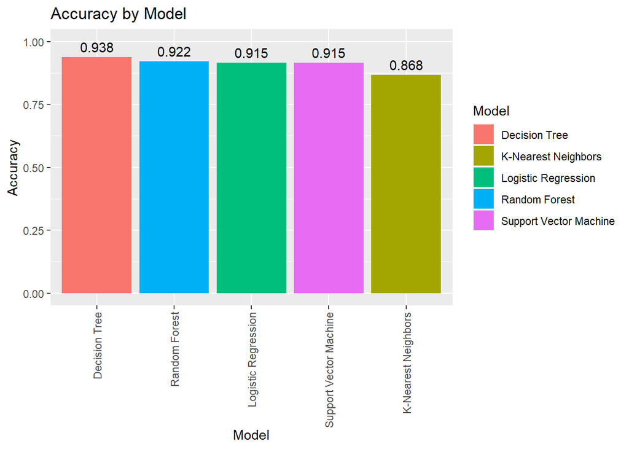

##### By Recall (Fail Class)

```r
show_recall_fail(df_eval_clf)
```

```
##                    Model Accuracy Precision.Fail Recall.Fail F1.Fail
## 1          Random Forest    0.922          0.778        0.70   0.737
## 2 Support Vector Machine    0.915          0.737        0.70   0.718
## 3    Logistic Regression    0.915          0.737        0.70   0.718
## 4          Decision Tree    0.938          0.929        0.65   0.765
## 5    K-Nearest Neighbors    0.868          0.615        0.40   0.485
##   Precision.Pass Recall.Pass F1.Pass
## 1          0.946       0.963   0.955
## 2          0.945       0.954   0.950
## 3          0.945       0.954   0.950
## 4          0.939       0.991   0.964
## 5          0.897       0.954   0.924
```

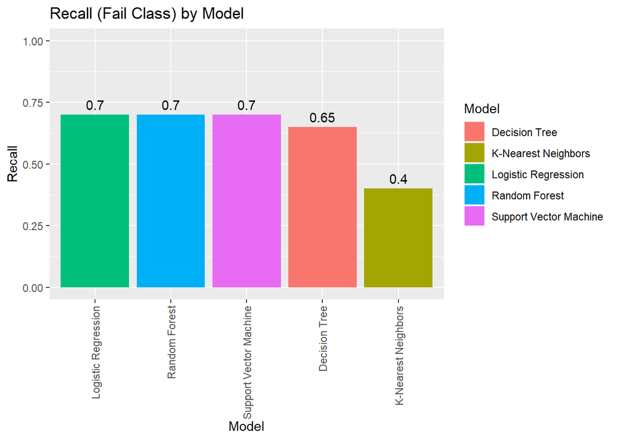

#### 2. Down-Sampled Train Set

```r
down_df_eval_clf <- rbind(
  down_dt_metrics_clf,
  down_rf_metrics_clf,
  down_svm_poly_metrics_clf,
  down_knn_metrics_clf,
  down_lr_metrics_clf
)

down_df_eval_clf
```

```
##                    Model Accuracy Precision.Fail Recall.Fail F1.Fail
## 1          Decision Tree    0.860          0.531        0.85   0.654
## 2          Random Forest    0.876          0.567        0.85   0.680
## 3 Support Vector Machine    0.860          0.529        0.90   0.667
## 4    K-Nearest Neighbors    0.853          0.516        0.80   0.627
## 5    Logistic Regression    0.876          0.562        0.90   0.692
##   Precision.Pass Recall.Pass F1.Pass
## 1          0.969       0.862   0.913
## 2          0.970       0.881   0.923
## 3          0.979       0.853   0.912
## 4          0.959       0.862   0.908
## 5          0.979       0.872   0.922
```

##### By Accuracy

```r
show_accuracy(down_df_eval_clf)
```

```
##                    Model Accuracy Precision.Fail Recall.Fail F1.Fail
## 1          Random Forest    0.876          0.567        0.85   0.680
## 2    Logistic Regression    0.876          0.562        0.90   0.692
## 3          Decision Tree    0.860          0.531        0.85   0.654
## 4 Support Vector Machine    0.860          0.529        0.90   0.667
## 5    K-Nearest Neighbors    0.853          0.516        0.80   0.627
##   Precision.Pass Recall.Pass F1.Pass
## 1          0.970       0.881   0.923
## 2          0.979       0.872   0.922
## 3          0.969       0.862   0.913
## 4          0.979       0.853   0.912
## 5          0.959       0.862   0.908
```

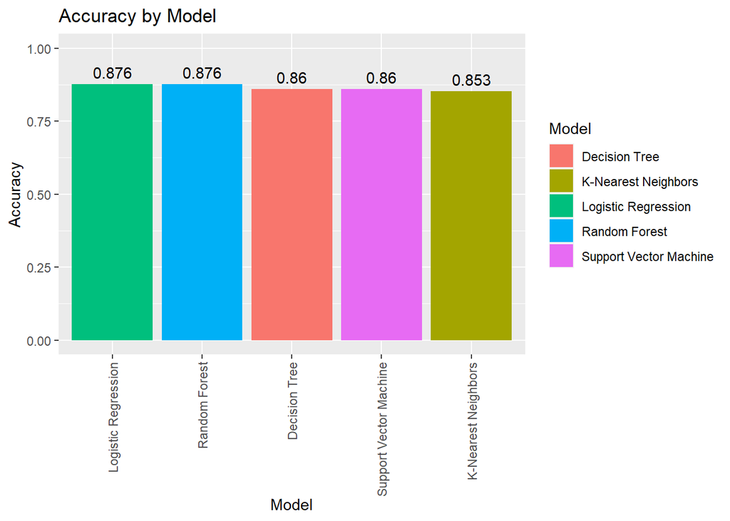

##### By Recall (Fail Class)

```r
show_recall_fail(down_df_eval_clf)
```

```
##                    Model Accuracy Precision.Fail Recall.Fail F1.Fail
## 1 Support Vector Machine    0.860          0.529        0.90   0.667
## 2    Logistic Regression    0.876          0.562        0.90   0.692
## 3          Decision Tree    0.860          0.531        0.85   0.654
## 4          Random Forest    0.876          0.567        0.85   0.680
## 5    K-Nearest Neighbors    0.853          0.516        0.80   0.627
##   Precision.Pass Recall.Pass F1.Pass
## 1          0.979       0.853   0.912
## 2          0.979       0.872   0.922
## 3          0.969       0.862   0.913
## 4          0.970       0.881   0.923
## 5          0.959       0.862   0.908
```

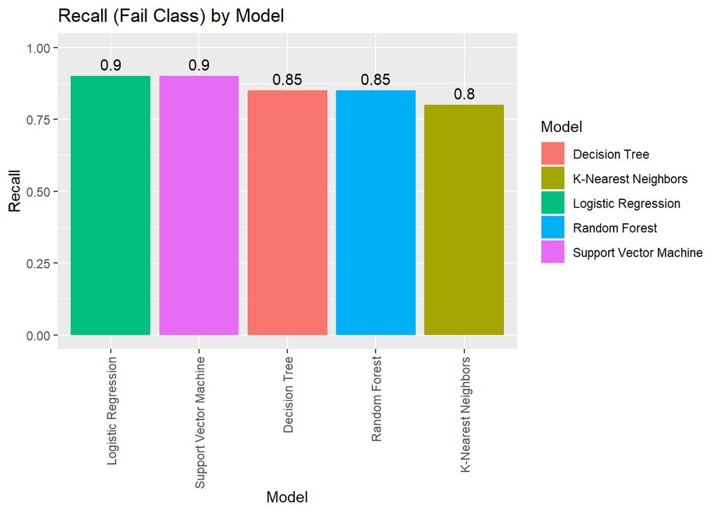

#### 3. Up-Sampled Train Set

```r
up_df_eval_clf <- rbind(
  up_dt_metrics_clf,
  up_rf_metrics_clf,
  up_svm_poly_metrics_clf,
  up_knn_metrics_clf,
  up_lr_metrics_clf
)

up_df_eval_clf
```

```
##                    Model Accuracy Precision.Fail Recall.Fail F1.Fail
## 1          Decision Tree    0.884          0.593        0.80   0.681
## 2          Random Forest    0.915          0.800        0.60   0.686
## 3 Support Vector Machine    0.891          0.875        0.35   0.500
## 4    K-Nearest Neighbors    0.891          0.714        0.50   0.588
## 5    Logistic Regression    0.884          0.632        0.60   0.615
##   Precision.Pass Recall.Pass F1.Pass
## 1          0.961       0.899   0.929
## 2          0.930       0.972   0.951
## 3          0.893       0.991   0.939
## 4          0.913       0.963   0.938
## 5          0.927       0.936   0.932
```

##### By Accuracy

```r
show_accuracy(up_df_eval_clf)
```

```
##                    Model Accuracy Precision.Fail Recall.Fail F1.Fail
## 1          Random Forest    0.915          0.800        0.60   0.686
## 2 Support Vector Machine    0.891          0.875        0.35   0.500
## 3    K-Nearest Neighbors    0.891          0.714        0.50   0.588
## 4          Decision Tree    0.884          0.593        0.80   0.681
## 5    Logistic Regression    0.884          0.632        0.60   0.615
##   Precision.Pass Recall.Pass F1.Pass
## 1          0.930       0.972   0.951
## 2          0.893       0.991   0.939
## 3          0.913       0.963   0.938
## 4          0.961       0.899   0.929
## 5          0.927       0.936   0.932
```

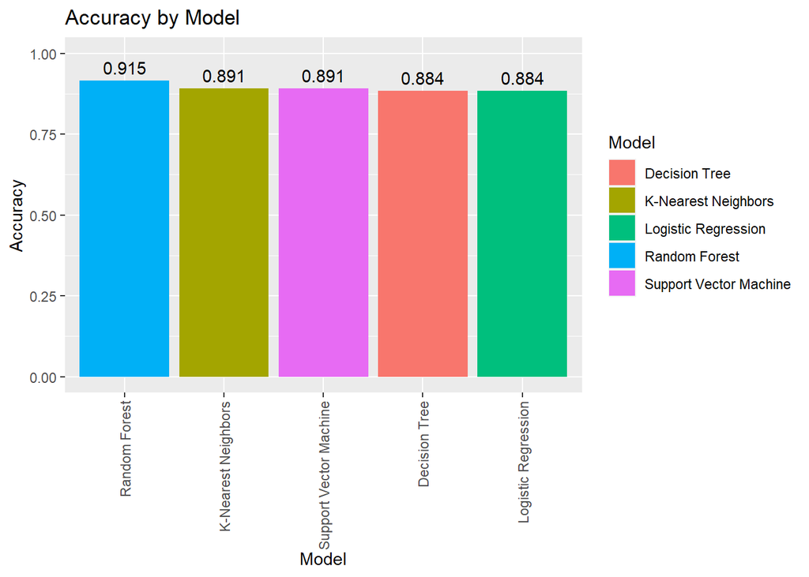

##### By Recall (Fail Class)

```r
show_recall_fail(up_df_eval_clf)
```

```
##                    Model Accuracy Precision.Fail Recall.Fail F1.Fail
## 1          Decision Tree    0.884          0.593        0.80   0.681
## 2          Random Forest    0.915          0.800        0.60   0.686
## 3    Logistic Regression    0.884          0.632        0.60   0.615
## 4    K-Nearest Neighbors    0.891          0.714        0.50   0.588
## 5 Support Vector Machine    0.891          0.875        0.35   0.500
##   Precision.Pass Recall.Pass F1.Pass
## 1          0.961       0.899   0.929
## 2          0.930       0.972   0.951
## 3          0.927       0.936   0.932
## 4          0.913       0.963   0.938
## 5          0.893       0.991   0.939
```

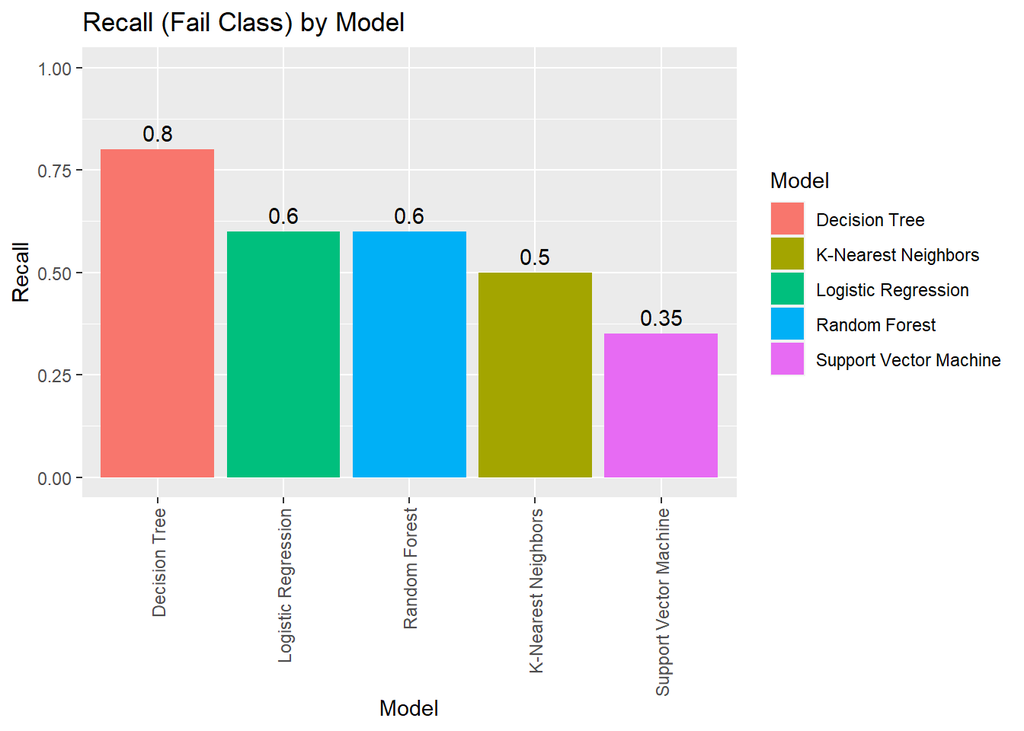

### Conclusion

In this study, we develop and evaluate the performance of different regression models and binary classification models to predict student performance in secondary education of two Portugese schools. G3, the final grade result is the target attribute in regression models while in binary classification models, the target attribute “result” is created by segregating the G3 result into binary labels “pass” and “fail”. All the models are trained with hyperparameter tuning to optimize their performance.

From the EDA result, we discovered that the attributes G1 and G2 are highly correlated to the target attribute G3. It shown that students that achieved higher G1 and G2 results are most likely to achieve higher G3 result.

We aim to achieve better prediction result compared to previous study by Cortez and Silva (2008) where the study achieved RMSE of 1.32 and accuracy of 93% from their best regression model and binary classification model respectively. The research outcome shown that our best models slightly outperformed the result from previous study with RMSE of 1.11 from regression model using Random Forest and accuracy of 93.8% from binary classification model using Decision Tree.

In addition, we noticed the issue of imbalanced data with 440 pass label and 80 fail label in training dataset. Thus we have also trained the binary classification models using down-sampling and up-sampling data. We have compared the result of classification models using original sample data, down-sampled data, and up-sampled data.

Due to the imbalanced classes in the original sample data, accuracy is not the best metric to evaluate the model performance. Furthermore, we would like to emphasize our prediction in the fail class. Hence, we decided to use recall as the main metric.

For classification using the original data, Random Forest, Support Vector Machine and Logistic Regression were performing equally well in terms of recall. In comparison to the models from down-sampled and up-sampled data, Logistic Regression and Support Vector Machine from down-sampled data produced the best results with 90% recall.

In future work, G1 and G2 attributes can be removed from the features so that we can further study the impact of other attributes to student performance to address a more specific problem. For instance, future work can be conducted to study whether family background affects student’s academic result by predicting student performance with their family ecological factors.